# Homework 5

Wenxiao Yang

## Part II: Homework Questions – to be submitted

1. If $n=p$ and the $\mathbf{X}$ matrix is invertible, show that the hat matrix $\mathbf{H}$ is given by the $p\times p$ identity matrix. In this case, what are $h_{ii}$ and $\hat{Y}_{i}$? Since $n=p$ and $\mathbf{X}_{n\times p}$ is invertible, exists $\mathbf{X}^{-1}$ and $(\mathbf{X}^T)^{-1}$ s.t.
   $$\mathbf{X}\mathbf{X}^{-1}=\mathbf{X}^{-1}\mathbf{X}=\mathbf{X}^T(\mathbf{X}^T)^{-1}=(\mathbf{X}^T)^{-1}\mathbf{X}^T=\mathbf{I}_{p\times p}$$
   Then,
   $$\mathbf{X}^T\mathbf{H}=\mathbf{X}^T\mathbf{X}(\mathbf{X}^T\mathbf{X})^{-1}\mathbf{X}^T=\mathbf{X}^T$$
   $$\mathbf{H}=(\mathbf{X}^T)^{-1}\mathbf{X}^T\mathbf{H}=(\mathbf{X}^T)^{-1}\mathbf{X}^T=\mathbf{I}_{p\times p}$$
   Then
   $$h_{ii}=1,\ \hat{\mathbf{Y}}_i=y_i$$
2. The `whitewines.csv` data set contains information related to white variants of the Portuguese “*Vinho Verde*” wine. Specifically, we have recorded the following information:
   1. fixed acidity, (b) volatile acidity, (c) citric acid , (d) residual sugar, (e) chlorides, (f) free sulfur dioxide, (g) total sulfur dioxide, (h) density, (i) pH, (j) sulphates, (k) alcohol, (l) quality (score between 0 and 10)

   In this homework, our goal is to explain the relationship between alcohol level (dependent variable) and residual sugar, pH, density and fixed acidity.

   ```r
   whitewines<-read.csv("whitewines.csv",sep = ";")
   whitewines.reg=whitewines[,c(-2,-3,-5,-6,-7,-10,-12)]
   whitewines.mlr=lm(alcohol~residual.sugar+pH+density+fixed.acidity,data=whitewines.reg)
   summary(whitewines.mlr)
   ```

   ```
   ##
   ## Call:
   ## lm(formula = alcohol ~ residual.sugar + pH + density + fixed.acidity,
   ##     data = whitewines.reg)
   ##
   ## Residuals:
   ##     Min      1Q  Median      3Q     Max
   ## -3.3867 -0.2735 -0.0334  0.2200 16.9366
   ##
   ## Coefficients:
   ##                  Estimate Std. Error t value Pr(>|t|)
   ## (Intercept)     6.790e+02  4.540e+00  149.56   <2e-16 ***
   ## residual.sugar  2.367e-01  2.702e-03   87.58   <2e-16 ***
   ## pH              2.535e+00  5.281e-02   48.01   <2e-16 ***
   ## density        -6.858e+02  4.664e+00 -147.05   <2e-16 ***
   ## fixed.acidity   5.352e-01  9.858e-03   54.30   <2e-16 ***
   ## ---
   ## Signif. codes:  0 '***' 0.001 '**' 0.01 '*' 0.05 '.' 0.1 ' ' 1
   ##
   ## Residual standard error: 0.4702 on 4893 degrees of freedom
   ## Multiple R-squared:  0.8542, Adjusted R-squared:  0.854
   ## F-statistic:  7164 on 4 and 4893 DF,  p-value: < 2.2e-16
   ```

   1. Check the constant variance assumption.

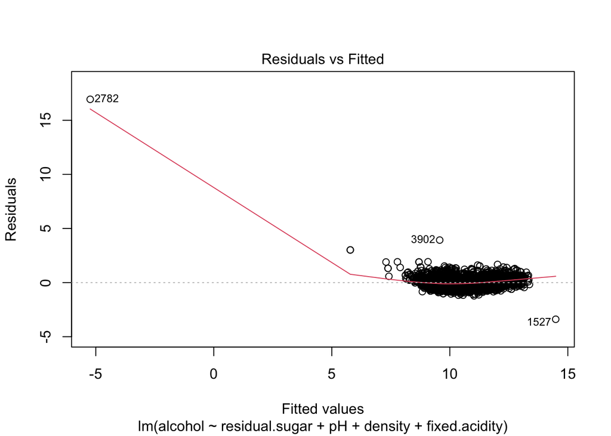

   ```r
   plot(whitewines.mlr, which=1)
   ```

   ```r
   library(lmtest)
   bptest(whitewines.mlr)
   ```

   ```
   ##
   ##  studentized Breusch-Pagan test
   ##
   ## data:  whitewines.mlr
   ## BP = 250.65, df = 4, p-value < 2.2e-16
   ```

   p-value is low, we reject the null hypothesis of constant variace.
   2. Check the normality assumption.

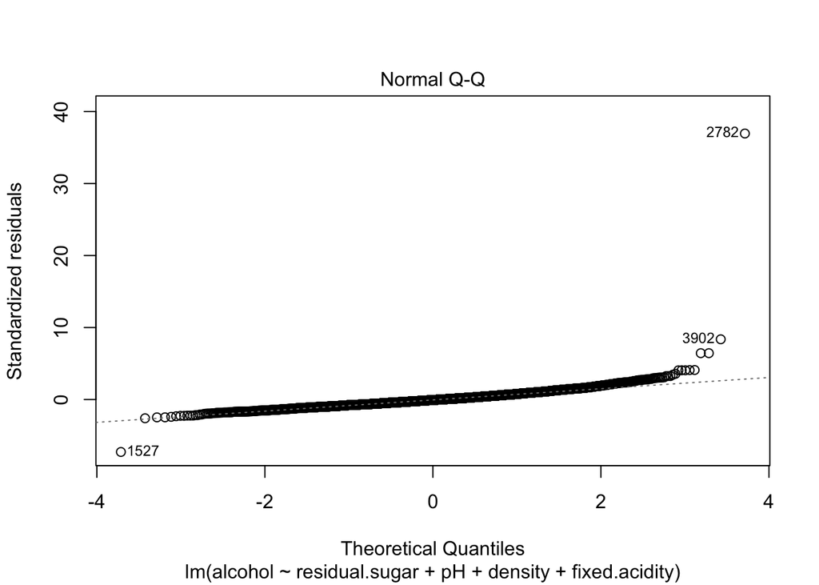

   ```r
   plot(whitewines.mlr,which=2)
   ```

   ```r
   ks.test(residuals(whitewines.mlr),y=pnorm)
   ```

   ```
   ##
   ##  One-sample Kolmogorov-Smirnov test
   ##
   ## data:  residuals(whitewines.mlr)
   ## D = 0.23173, p-value < 2.2e-16
   ## alternative hypothesis: two-sided
   ```

   Low p-value, we reject the normality assumption.
   3. Check for the structure of the relationship between the predictors and the response.

   ```r
   summary(whitewines.mlr)
   ```

   ```
   ##
   ## Call:
   ## lm(formula = alcohol ~ residual.sugar + pH + density + fixed.acidity,
   ##     data = whitewines.reg)
   ##
   ## Residuals:
   ##     Min      1Q  Median      3Q     Max
   ## -3.3867 -0.2735 -0.0334  0.2200 16.9366
   ##
   ## Coefficients:
   ##                  Estimate Std. Error t value Pr(>|t|)
   ## (Intercept)     6.790e+02  4.540e+00  149.56   <2e-16 ***
   ## residual.sugar  2.367e-01  2.702e-03   87.58   <2e-16 ***
   ## pH              2.535e+00  5.281e-02   48.01   <2e-16 ***
   ## density        -6.858e+02  4.664e+00 -147.05   <2e-16 ***
   ## fixed.acidity   5.352e-01  9.858e-03   54.30   <2e-16 ***
   ## ---
   ## Signif. codes:  0 '***' 0.001 '**' 0.01 '*' 0.05 '.' 0.1 ' ' 1
   ##
   ## Residual standard error: 0.4702 on 4893 degrees of freedom
   ## Multiple R-squared:  0.8542, Adjusted R-squared:  0.854
   ## F-statistic:  7164 on 4 and 4893 DF,  p-value: < 2.2e-16
   ```

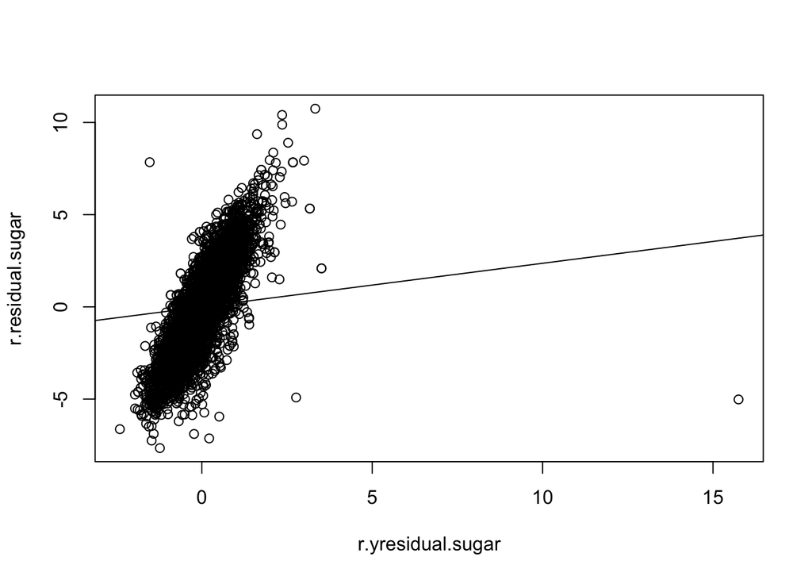

   ```r
   # residual.sugar variable removed
   r.yresidual.sugar = update(whitewines.mlr, ~pH+density+fixed.acidity)$res
   r.residual.sugar = lm(residual.sugar~pH+density+fixed.acidity,data=whitewines.reg)$res
   tmp1=lm(r.yresidual.sugar ~ r.residual.sugar)
   # pH variable removed
   r.ypH = update(whitewines.mlr, ~residual.sugar+density+fixed.acidity)$res
   r.pH = lm(pH~residual.sugar+density+fixed.acidity,data=whitewines.reg)$res
   tmp2=lm(r.ypH ~ r.pH)
   # density variable removed
   r.ydensity = update(whitewines.mlr, ~residual.sugar+pH+fixed.acidity)$res
   r.density = lm(density~residual.sugar+pH+fixed.acidity,data=whitewines.reg)$res
   tmp3=lm(r.ydensity ~ r.density)
   # fixed.acidity variable removed
   r.yfixed.acidity = update(whitewines.mlr, ~residual.sugar+pH+density)$res
   r.fixed.acidity = lm(fixed.acidity~residual.sugar+pH+density,data=whitewines.reg)$res
   tmp4=lm(r.yfixed.acidity ~ r.fixed.acidity)

   plot(r.yresidual.sugar, r.residual.sugar); abline(tmp1)
   ```

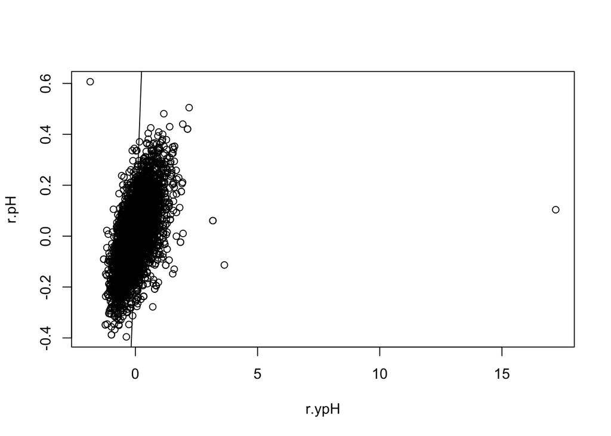

   ```r
   plot(r.ypH, r.pH); abline(tmp2)
   ```

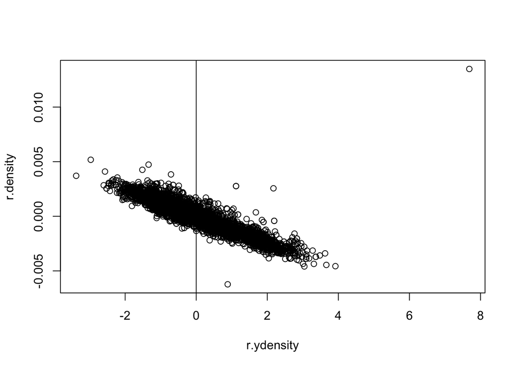

   ```r
   plot(r.ydensity, r.density); abline(tmp3)
   ```

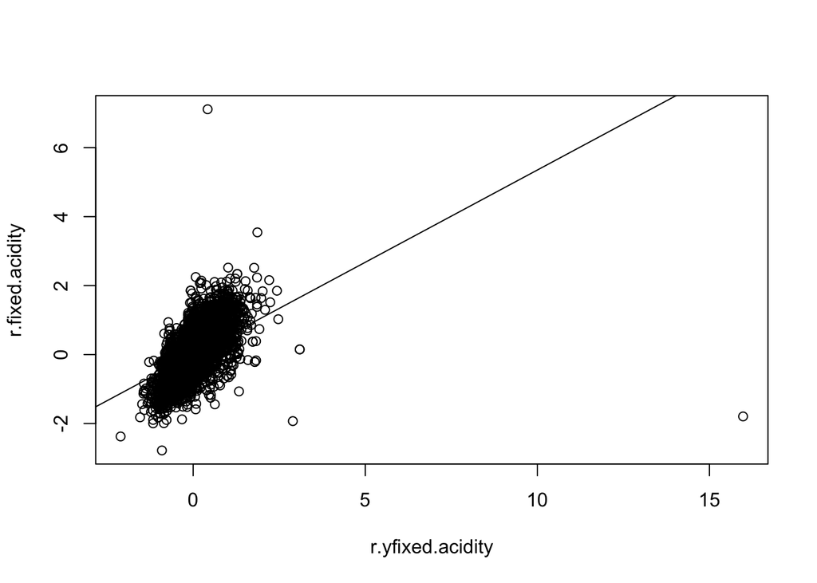

   ```r
   plot(r.yfixed.acidity, r.fixed.acidity); abline(tmp4)
   ```

   ```r
   whitewines.mlr.log=lm(log(alcohol)~residual.sugar+pH+density+fixed.acidity,data=whitewines.reg)
   bptest(whitewines.mlr.log)
   ```

   ```
   ##
   ##  studentized Breusch-Pagan test
   ##
   ## data:  whitewines.mlr.log
   ## BP = 263.17, df = 4, p-value < 2.2e-16
   ```

   ```r
   ks.test(residuals(whitewines.mlr.log),y=pnorm)
   ```

   ```
   ##
   ##  One-sample Kolmogorov-Smirnov test
   ##
   ## data:  residuals(whitewines.mlr.log)
   ## D = 0.46055, p-value < 2.2e-16
   ## alternative hypothesis: two-sided
   ```

   ```r
   whitewines.mlr.frac=lm(1/alcohol~residual.sugar+pH+density+fixed.acidity,data=whitewines.reg)
   bptest(whitewines.mlr.frac)
   ```

   ```
   ##
   ##  studentized Breusch-Pagan test
   ##
   ## data:  whitewines.mlr.frac
   ## BP = 274.49, df = 4, p-value < 2.2e-16
   ```

   ```r
   ks.test(residuals(whitewines.mlr.frac),y=pnorm)
   ```

   ```
   ##
   ##  One-sample Kolmogorov-Smirnov test
   ##
   ## data:  residuals(whitewines.mlr.frac)
   ## D = 0.49514, p-value < 2.2e-16
   ## alternative hypothesis: two-sided
   ```

   ```r
   whitewines.mlr.sqrt=lm(sqrt(alcohol)~residual.sugar+pH+density+fixed.acidity,data=whitewines.reg)
   bptest(whitewines.mlr.sqrt)
   ```

   ```
   ##
   ##  studentized Breusch-Pagan test
   ##
   ## data:  whitewines.mlr.sqrt
   ## BP = 257.12, df = 4, p-value < 2.2e-16
   ```

   ```r
   ks.test(residuals(whitewines.mlr.sqrt),y=pnorm)
   ```

   ```
   ##
   ##  One-sample Kolmogorov-Smirnov test
   ##
   ## data:  residuals(whitewines.mlr.sqrt)
   ## D = 0.44136, p-value < 2.2e-16
   ## alternative hypothesis: two-sided
   ```

   There is no simple transformation of the predictors suggested. May be Box-Cox Transformation will be better?
   5. Use the Box-Cox method to determine an optimal transformation of the response. Would it be reasonable to leave the response untransformed?

   ```r
   library(MASS)
   min(whitewines.reg$alcohol)
   ```

   ```
   ## [1] 8
   ```

   ```r
   whitewines.transformation=boxcox(whitewines.mlr, lambda=seq(-2, 2, length=400))
   ```

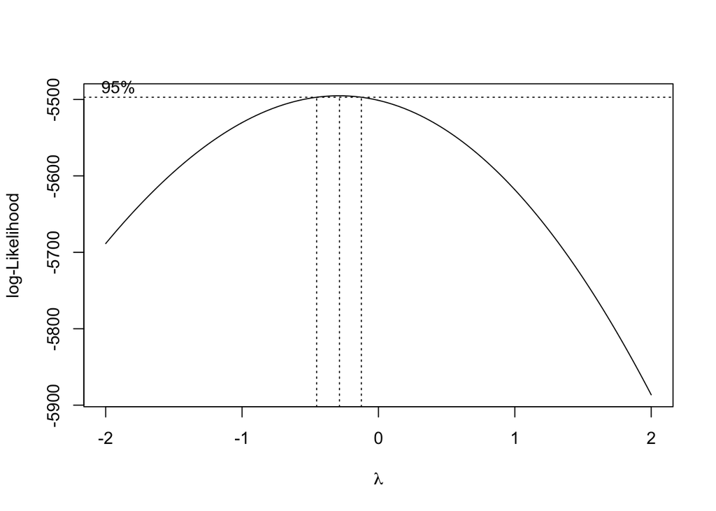

   ```r
   lambda=whitewines.transformation$x[whitewines.transformation$y == max(whitewines.transformation$y)]
   lambda
   ```

   ```
   ## [1] -0.2857143
   ```

   ```r
   whitewines.reg$g_alcohol=(whitewines.reg$alcohol^lambda-1)/lambda
   whitewines.mlr.new=lm(g_alcohol~residual.sugar+pH+density+fixed.acidity,data=whitewines.reg)
   summary(whitewines.mlr.new)
   ```

   ```
   ##
   ## Call:
   ## lm(formula = g_alcohol ~ residual.sugar + pH + density + fixed.acidity,
   ##     data = whitewines.reg)
   ##
   ## Residuals:
   ##      Min       1Q   Median       3Q      Max
   ## -0.16219 -0.01280 -0.00058  0.01047  0.81170
   ##
   ## Coefficients:
   ##                  Estimate Std. Error t value Pr(>|t|)
   ## (Intercept)     3.311e+01  2.168e-01  152.67   <2e-16 ***
   ## residual.sugar  1.087e-02  1.291e-04   84.22   <2e-16 ***
   ## pH              1.240e-01  2.522e-03   49.14   <2e-16 ***
   ## density        -3.223e+01  2.228e-01 -144.70   <2e-16 ***
   ## fixed.acidity   2.600e-02  4.709e-04   55.21   <2e-16 ***
   ## ---
   ## Signif. codes:  0 '***' 0.001 '**' 0.01 '*' 0.05 '.' 0.1 ' ' 1
   ##
   ## Residual standard error: 0.02246 on 4893 degrees of freedom
   ## Multiple R-squared:  0.8531, Adjusted R-squared:  0.853
   ## F-statistic:  7106 on 4 and 4893 DF,  p-value: < 2.2e-16
   ```

   ```r
   bptest(whitewines.mlr.new)
   ```

   ```
   ##
   ##  studentized Breusch-Pagan test
   ##
   ## data:  whitewines.mlr.new
   ## BP = 266.48, df = 4, p-value < 2.2e-16
   ```

   ```r
   ks.test(residuals(whitewines.mlr.new),y=pnorm)
   ```

   ```
   ##
   ##  One-sample Kolmogorov-Smirnov test
   ##
   ## data:  residuals(whitewines.mlr.new)
   ## D = 0.47769, p-value < 2.2e-16
   ## alternative hypothesis: two-sided
   ```

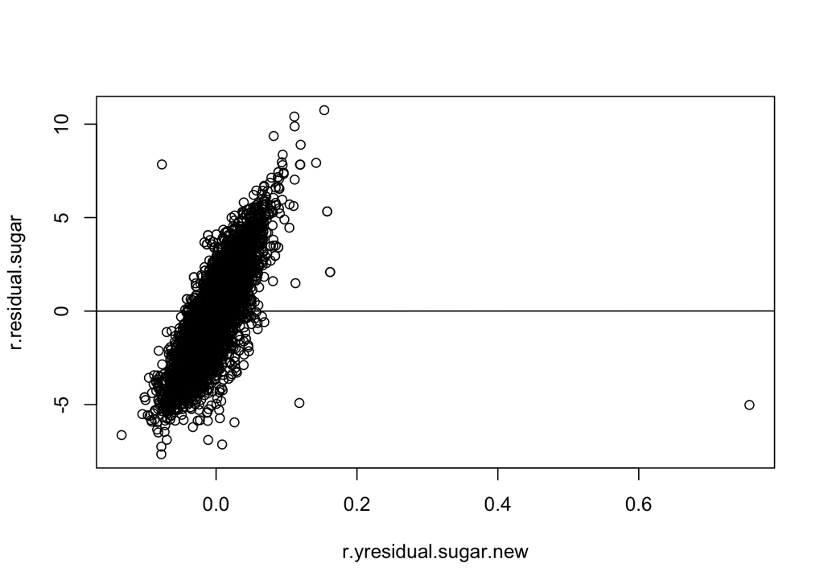

   ```r
   # residual.sugar variable removed
   r.yresidual.sugar.new = update(whitewines.mlr.new, ~pH+density+fixed.acidity)$res
   r.residual.sugar = lm(residual.sugar~pH+density+fixed.acidity,data=whitewines.reg)$res
   tmp1.new=lm(r.yresidual.sugar.new ~ r.residual.sugar)
   # pH variable removed
   r.ypH.new = update(whitewines.mlr.new, ~residual.sugar+density+fixed.acidity)$res
   r.pH = lm(pH~residual.sugar+density+fixed.acidity,data=whitewines.reg)$res
   tmp2.new=lm(r.ypH.new ~ r.pH)
   # density variable removed
   r.ydensity.new = update(whitewines.mlr.new, ~residual.sugar+pH+fixed.acidity)$res
   r.density = lm(density~residual.sugar+pH+fixed.acidity,data=whitewines.reg)$res
   tmp3.new=lm(r.ydensity.new ~ r.density)
   # fixed.acidity variable removed
   r.yfixed.acidity.new = update(whitewines.mlr.new, ~residual.sugar+pH+density)$res
   r.fixed.acidity = lm(fixed.acidity~residual.sugar+pH+density,data=whitewines.reg)$res
   tmp4.new=lm(r.yfixed.acidity.new ~ r.fixed.acidity)

   plot(r.yresidual.sugar.new, r.residual.sugar); abline(tmp1.new)
   ```

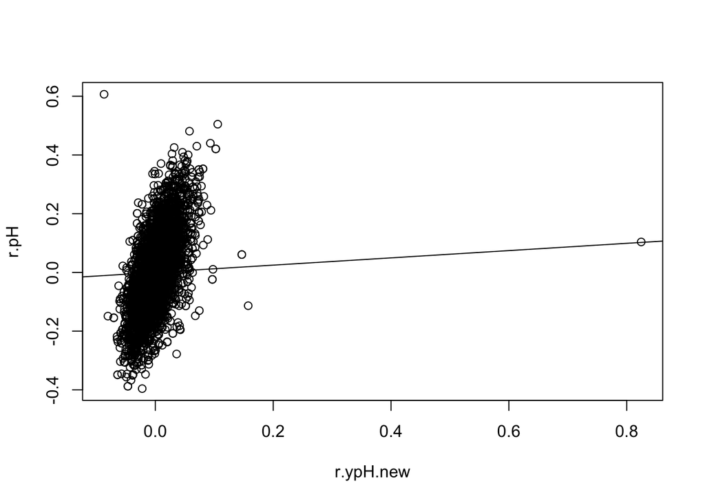

   ```r
   plot(r.ypH.new, r.pH); abline(tmp2.new)
   ```

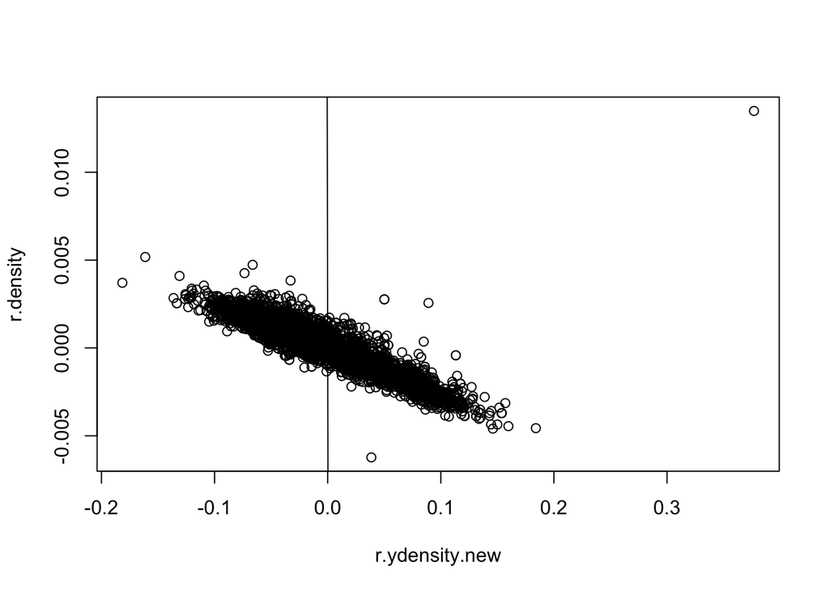

   ```r
   plot(r.ydensity.new, r.density); abline(tmp3.new)
   ```

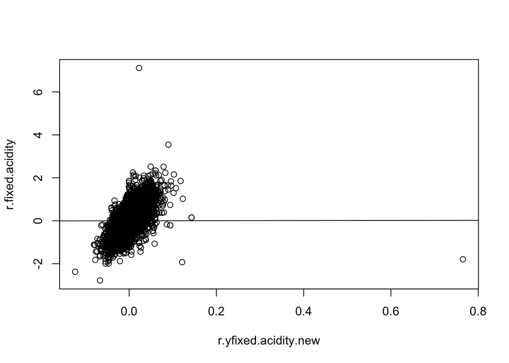

   ```r
   plot(r.yfixed.acidity.new, r.fixed.acidity); abline(tmp4.new)
   ```

   Looks like helps a liitle in the linearity. Not making any difference.